# Logistic Regression and Random Forest to Determine Credit Card Default

## Random Forest

Another prediction model used is random forest. Random forest is a classifying method consisting of many decision trees. By creating a “forest” of decision trees, the classifying model hopes to select it’s best model by running many different decision trees and “takes the majority” to determine classification. To do so, random forest uses out-of-bag sampling.

A random forest model is created to determine the probability of credit card default:

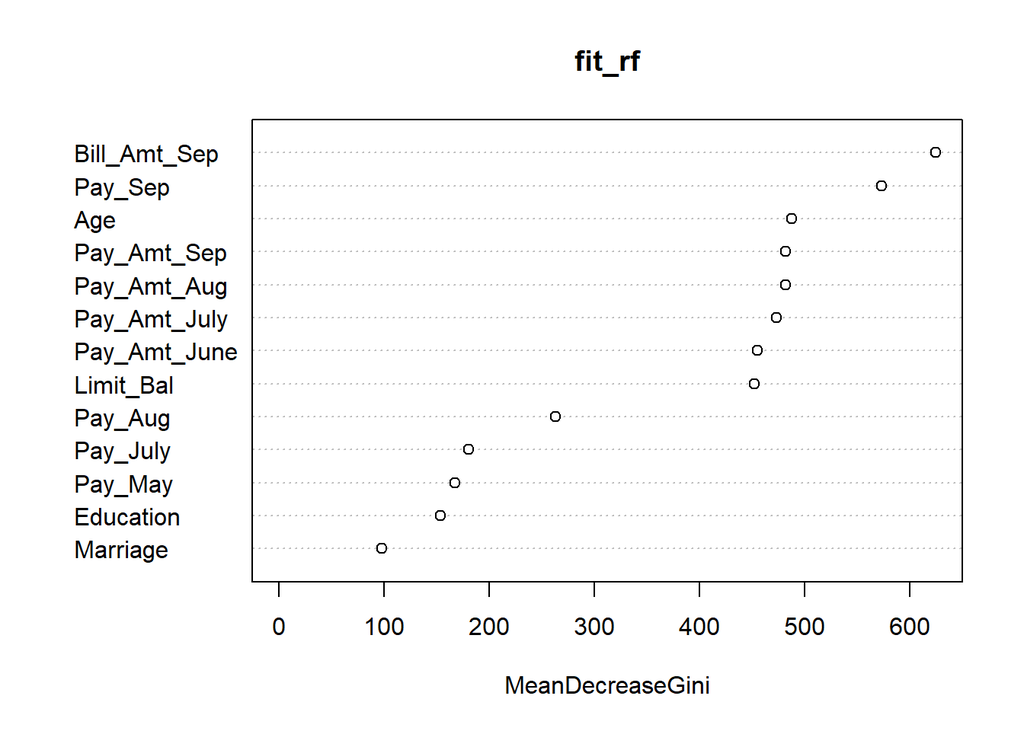

```r
set.seed(123)

n_defaults <- sum(train_set$Default == 1)

#Random Forest for variables. mtry = 4 since there are 13 variables (square root of 11 is close to 4).
fit_rf <- randomForest(factor(Default) ~Limit_Bal+Education+Marriage+Age+Pay_Sep+Pay_Aug+Pay_July+
                  Pay_May+Bill_Amt_Sep+Pay_Amt_Sep+Pay_Amt_Aug
                  +Pay_Amt_July+Pay_Amt_June,
                  mtry = 4, ntree = 1000, sampsize = c(n_defaults, n_defaults),
                   strata = factor(train_set$Default), data = train_set)
varImpPlot(fit_rf)
```

```r
#Predicts values in the test set.
predict_rf <- predict(fit_rf, test_set)
#Creates the confusion matrix table for the random forest model.
confusion_table_rf <- table(test_set$Default, predict_rf)
#Creates and displays the confusion matrix statistics for the random forest model.
cm_rf <- confusionMatrix(confusion_table_rf, positive = '1', mode = "everything")
cm_rf
```

```
## Confusion Matrix and Statistics
##
##    predict_rf
##        0    1
##   0 4969  879
##   1  680  960
##
##                Accuracy : 0.7918
##                  95% CI : (0.7824, 0.8009)
##     No Information Rate : 0.7544
##     P-Value [Acc > NIR] : 1.079e-14
##
##                   Kappa : 0.4169
##
##  Mcnemar's Test P-Value : 5.313e-07
##
##             Sensitivity : 0.5220
##             Specificity : 0.8796
##          Pos Pred Value : 0.5854
##          Neg Pred Value : 0.8497
##               Precision : 0.5854
##                  Recall : 0.5220
##                      F1 : 0.5519
##              Prevalence : 0.2456
##          Detection Rate : 0.1282
##    Detection Prevalence : 0.2190
##       Balanced Accuracy : 0.7008
##
##        'Positive' Class : 1
##
```

```r
#Saves the accuracy, precision, and recall values.
rf_accuracy = accuracy(test_set$Default, predict_rf)
rf_precision = cm_rf$byClass['Precision']
rf_recall = cm_rf$byClass['Recall']
rf_pos_precision = cm_rf$byClass['Pos Pred Value']
#Prints the accuracy, total precision, recall, and default precision values.
print(paste("Accuracy: ", round(rf_accuracy,3)))
```

```
## [1] "Accuracy:  0.792"
```

```r
print(paste("Precision: ", round(rf_precision,3)))
```

```
## [1] "Precision:  0.585"
```

```r
print(paste("Recall: ", round(rf_recall,3)))
```

```
## [1] "Recall:  0.522"
```

```r
print(paste("Default Precision: ", round(rf_pos_precision,3)))
```

```
## [1] "Default Precision:  0.585"
```

From the input printed and the plot provided, it is seen that the pay September variable and bill amount in September, as well as age are important variables in determining credit card default. It can also be argued pay amount in September, pay amount in August and pay amount in July are important variables in determining credit card default.

## Conclusion

In this project, logistic regression and random forest models were created to predict if an individual would default on their credit card.

First, the data was cleaned for accuracy and manipulated to view distributions and trends in the data. From the tables and plots created, the data had more females than males and was skewed in age, with participants below the age of 40 much more prevalent than participants over the age of 40.

A random forest model was also created to determine the most important variables in a prediction model, as well as to see the accuracy of the created model. From the results, the random forest model could accurately predict someone not defaulting on their credit card, but had a more difficult time accurately predicting when someone would default on their credit card.

When comparing the two models, the following table was created:

```r
set.caption("Performance for Logistic Regression and Random Forest Models")
data.table = rbind(c(log_accuracy_opt, log_precision_opt, log_recall_opt, log_pos_precision_opt), c(rf_accuracy, rf_precision, rf_recall, rf_pos_precision))
colnames(data.table) = c("Accuracy", "Precision", "Recall", "Default Precision")
rownames(data.table) = c("Logistic Regression", "Random Forest")

pander(data.table)
```

Performance for Logistic Regression and Random Forest Models

|  | Accuracy | Precision | Recall | Default Precision |
| --- | --- | --- | --- | --- |
| **Logistic Regression** | 0.8114 | 0.1982 | 0.7701 | 0.9834 |
| **Random Forest** | 0.7918 | 0.5854 | 0.522 | 0.5854 |

Though these prediction models are acceptable, there is room for improvement, particularly in accurately predicting client that will default. I believe adding certain variables such as credit score, credit age, and credit card utilization can help improve the prediction models.

Thank you for viewing my project.